# Year 1 Pennsylvania Data Exploration

# Capture & Visual Encounter Surveys

$~$

### Load and Wrangle Capture Data

$~$

#### Load data

```r
cap <- read_csv(here("data", "cap.csv")) %>%
  clean_names()
```

$~$

#### Wrangle Capture data and join with VES data

```r
capture <- cap %>%
  mutate(count = 1) %>%
  group_by(site, species_capture) %>%
  summarise(count = sum(count),
            species_capture = species_capture) %>%
  mutate(repeat_id = cur_group_id(),
         species_capture = str_replace(species_capture, "possibly", ""),
         species_capture = str_replace(species_capture, "[[:punct:]]", "")) %>%
  filter(!duplicated(repeat_id)) %>%
  filter(!species_capture == "negative control") %>%
  select(!repeat_id) %>%
  rename(capture_count = count) %>%
  mutate(species_capture = as.factor(species_capture))

capture$capture_scaled_count<- ((capture$capture_count/ sum(capture$capture_count))*100) %>%
  round(digits = 2)

visual_join <- visual %>%
  rename(visual_count = count,
         visual_scaled_count = scaled_count)

# percent occurrence for plots
comb_data <- merge(capture, visual_join, by.x = c("site", "species_capture"), by.y = c("site", "species_ves")) %>%
  rename(species = species_capture) %>%
  select(!c(capture_count, visual_count)) %>%
  pivot_longer(!c(site, species), names_to = "capture_ves", values_to = "scaled_count") %>%
  mutate(species = as.factor(species))


# log count data for ANOVA
comb_count <- merge(capture, visual_join, by.x = c("site", "species_capture"), by.y = c("site", "species_ves")) %>%
  rename(species = species_capture) %>%
  select(!c(capture_scaled_count, visual_scaled_count)) %>%
  pivot_longer(!c(site, species), names_to = "capture_ves", values_to = "scaled_count") %>%
  mutate(species = as.factor(species),
         log_count = log(scaled_count))
```

$~$

### Visualize All Capture Data

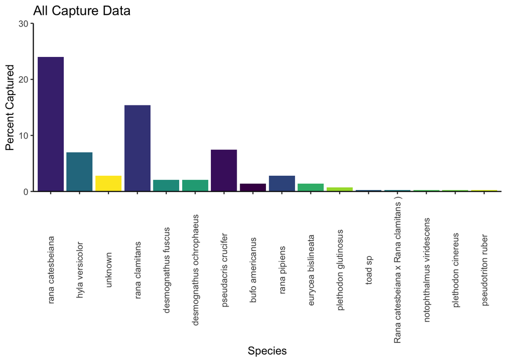

```r
ggplot(data = capture, aes(x = reorder(species_capture, -capture_scaled_count),
                           y = capture_scaled_count,
                           fill = species_capture)) +
  geom_col(stat = 'identity') +
  theme_classic()+
  theme(axis.text.x = element_text(angle = 90, vjust = 0.5),
        strip.background = element_blank(),
        legend.position = "none") +
  scale_fill_viridis_d(name = "Species") +
  scale_y_continuous(expand = c(0,0), limits = c(0,30)) +
  ylab("Percent Captured") +
  xlab("Species") +
  labs(title = "All Capture Data")
```

###### **Interpretation**: Of all the Capture Survey data, when looking at similar species from VES, we see Rana catesbeiana being captured the most, Rana clamitans captured the second most, and Rana pipiens being captured the 5th most.

$~$

### Visualize Capture and VES Data for Matching Sites and Species

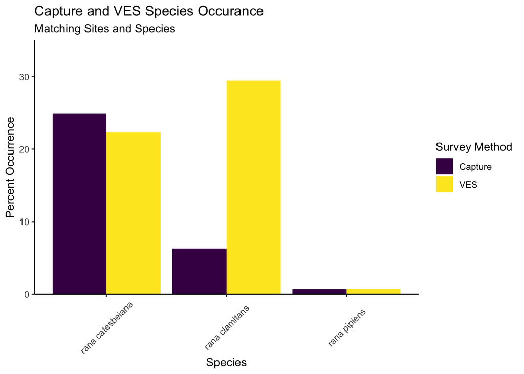

```r
ggplot(data = comb_data, aes(x = reorder(species, -scaled_count), y = scaled_count, fill = capture_ves)) +
  geom_col(stat = "identity", position = position_dodge()) +
  theme_classic()+
  theme(axis.text.x = element_text(angle = 45, vjust = 0.5),
        strip.background = element_blank()) +
  scale_fill_viridis_d(name = "Survey Method", labels = c("Capture", "VES")) +
  scale_y_continuous(expand = c(0,0), limits = c(0,35)) +
  ylab("Percent Occurrence") +
  xlab("Species") +
  labs(title = "Capture and VES Species Occurance",
       subtitle = "Matching Sites and Species")
```

###### **Interpretation**: When comparing the percent occurrence between the 3 similar species, 2 different survey types (Capture Surveys and VES), and sites where both occurred, we see similar percent occurrences for Rana catesbeiana and Rana pipiens and starkly different percent occurrences in Rana clamitans.

$~$

### All Capture and VES Matching Data

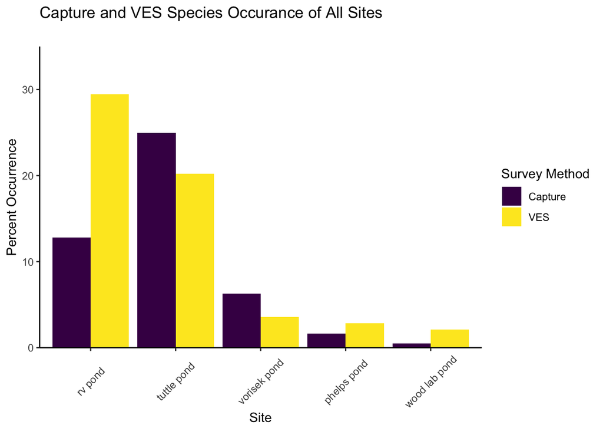

```r
ggplot(data = comb_data, aes(x = reorder(site, -scaled_count), y = scaled_count, fill = capture_ves)) +
  geom_col(stat = "identity", position = position_dodge()) +
  theme_classic()+
  theme(axis.text.x = element_text(angle = 45, vjust = 0.5),
        strip.background = element_blank()) +
  scale_fill_viridis_d(name = "Survey Method", labels = c("Capture", "VES")) +
  scale_y_continuous(expand = c(0,0), limits = c(0,35)) +
  ylab("Percent Occurrence") +
  xlab("Site") +
  labs(title = "Capture and VES Species Occurance of All Sites",
       subtitle = "")
```

###### **Interpretation**: When comparing percent occurrence between survey methods at matching survey sites we see no clear trend in percent occurrence.

$~$

### Analyse Capture and VES data

$~$

#### **Guiding Question**: Of repeated sites between survey methods, is there a difference in log count of species occurring between survey methods?

$~$

#### One-way ANOVA/T-test determining if the survey method affects the mean log count per species

$~$

###### **H0: There is no difference in mean log count per species between survey methods (Capture & VES)**

###### HA: There is a difference in mean log count per species between survey methods (Capture & VES)

```r
cap_ves <- aov(log_count ~ capture_ves, data = comb_count)
tidy(cap_ves) %>%
  kable(digits = 4) %>%
  kable_styling()
```

| term | df | sumsq | meansq | statistic | p.value |
| --- | --- | --- | --- | --- | --- |
| capture_ves | 1 | 0.1710 | 0.1710 | 0.0856 | 0.7728 |
| Residuals | 20 | 39.9371 | 1.9969 | NA | NA |

###### **Interpretation**: With an $\alpha$=0.05 we fail to reject the null indicating there is no difference in log count per species between survey methods.

$~$

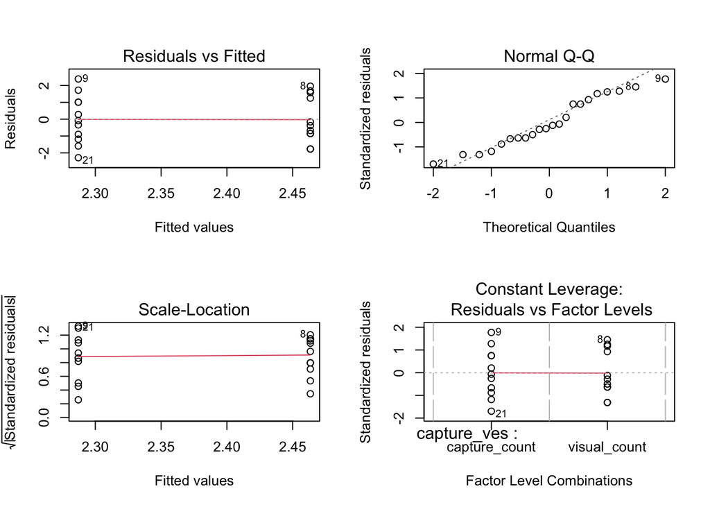

```r
par(mfrow=c(2,2))
plot(cap_ves)
```

```r
par(mfrow=c(1,1))
```

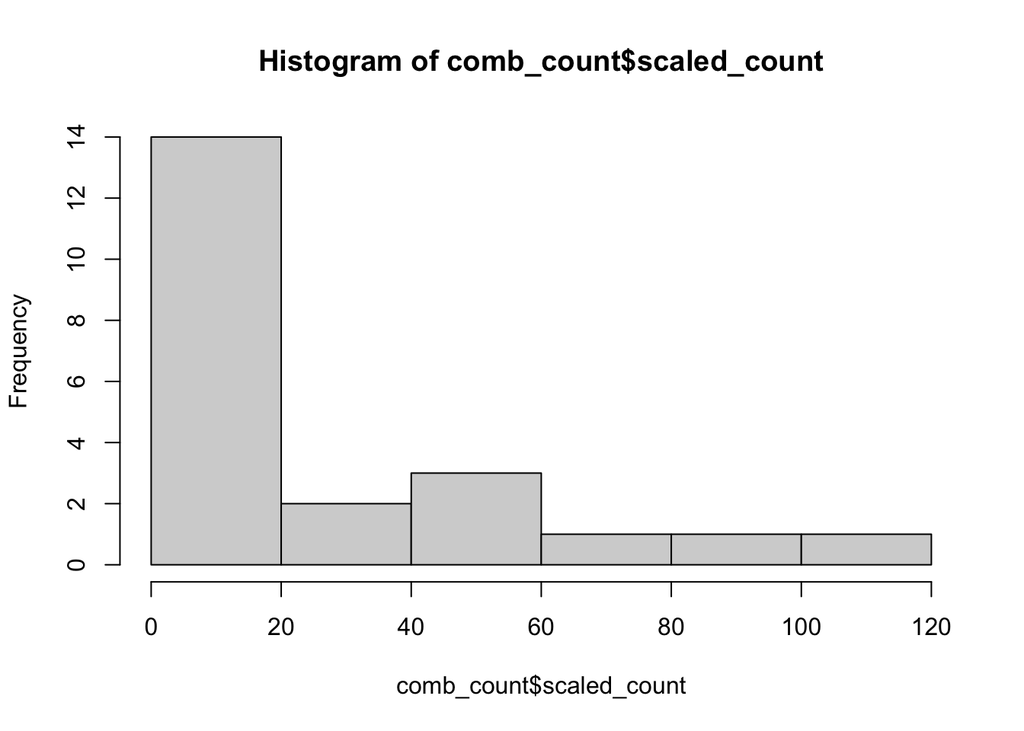

```r
hist(comb_count$scaled_count)
```

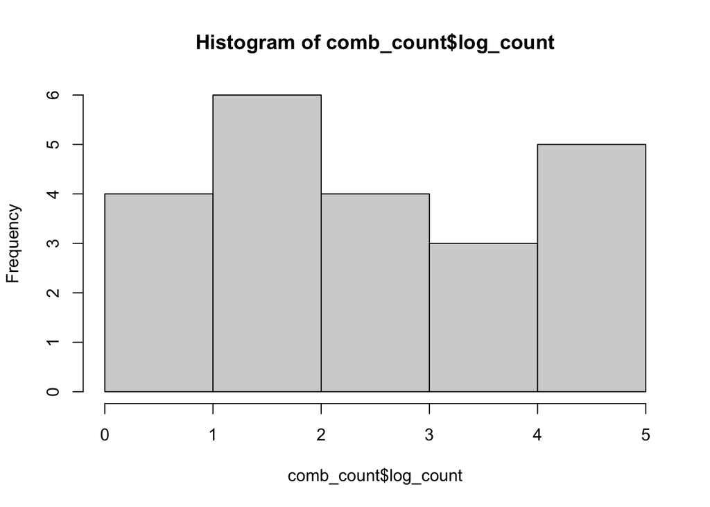

```r
hist(comb_count$log_count)
```

# GitHub

##### Github repository containing the reproducible script can be found [HERE](https://github.com/Jake-Eisaguirre/penn_year1_exploration). Cloning or Forking the repository to your own computer will allow for complete reproducibility of this data exploration.

$~$

# Exploratory Analysis

```r
ves_analsys_tuttle <- ves %>%
  select(c(site, date, species_ves, count)) %>%
  filter(site == "tuttle pond") %>%
  mutate(site = as.factor(site),
         date = as.factor(date),
         species_ves = as.factor(species_ves),
         log_count = log(count))

ves_analsys_tuttle$scaled_count<- ((ves_analsys_tuttle$count/ sum(ves_analsys_tuttle$count))*100)
```

$~$

#### **Guiding Question**: Of repeated VES at Tuttle Pond, is there a difference in mean log count between dates of surveys?

$~$

#### One-way ANOVA determining if date has an affect on mean log count per species at Tuttle Pond

$~$

###### H0: There is no difference in mean log count per species between the dates surveyed at Tuttle Pond

###### **HA: There is a difference in mean log count per species between the dates surveyed at Tuttle Pond**

```r
one_way_date <- aov(log_count ~ date, data = ves_analsys_tuttle)

tidy(one_way_date) %>%
  kable(digits = 2) %>%
  kable_styling()
```

| term | df | sumsq | meansq | statistic | p.value |
| --- | --- | --- | --- | --- | --- |
| date | 2 | 4.87 | 2.44 | 4.67 | 0.02 |
| Residuals | 28 | 14.61 | 0.52 | NA | NA |

###### **Interpretation**: With an $\alpha$=0.05 we reject the null hypothesis and expect date has an affect on mean log count for Tuttle Pond.

$~$

#### **Guiding Question**: Of repeated VES at Tuttle Pond, is there a difference in mean log count between species present?

$~$

#### One-way ANOVA determing if the species surveyed has an affect on mean log count per species at Tuttle Pond

$~$

###### **H0: There is no difference in meanlog count between species surveyed Tuttle Pond**

###### HA: There is a difference in mean log count per species between species surveyed Tuttle Pond

```r
one_way_species <- aov(log_count ~ species_ves, data = ves_analsys_tuttle)

tidy(one_way_species) %>%
  kable(digits = 2) %>%
  kable_styling()
```

| term | df | sumsq | meansq | statistic | p.value |
| --- | --- | --- | --- | --- | --- |
| species_ves | 2 | 1.79 | 0.90 | 1.42 | 0.26 |
| Residuals | 28 | 17.68 | 0.63 | NA | NA |

###### **Interpretation**: With an $\alpha$=0.05 we fail reject the null hypothesis and expect species surveyed does not affect in mean log count per species for Tuttle Pond.

$~$

#### **Guiding Question**: Of repeated VES at Tuttle Pond, is there a difference in mean log count as interaction between date and species present?

$~$

#### Two-way ANOVA determining if the species surveyed and date of survey has an affect on mean log count per species at Tuttle Pond

$~$

###### H0: There is no difference in mean log count per species from the dates surveyed and species surveyed at Tuttle Pond

###### HA: There is a difference in mean log count per species from the dates surveyed and species surveyed at Tuttle Pond

```r
two_way_species_date <- aov(log_count ~ date*species_ves, data = ves_analsys_tuttle)

tidy(two_way_species_date) %>%
  kable(digits = 2) %>%
  kable_styling()
```

| term | df | sumsq | meansq | statistic | p.value |
| --- | --- | --- | --- | --- | --- |
| date | 2 | 4.87 | 2.44 | 4.19 | 0.03 |
| species_ves | 2 | 0.29 | 0.14 | 0.25 | 0.78 |
| date:species_ves | 2 | 0.38 | 0.19 | 0.33 | 0.72 |
| Residuals | 24 | 13.94 | 0.58 | NA | NA |

$~$

#### **Guiding Question**: Of repeated sites, is there a difference in mean log count of species between sites?

$~$

#### One-way ANOVA/T-test determining if site has an affect on mean log count per species

$~$

###### H0: There is no difference on mean log count per species between repeated sites (Tuttle & Wood)

###### **HA: There is a difference in mean log countper species between repeated sites (Tuttle & Wood)**

```r
one_way_site <- aov(log_count ~ site, data = combine_analysis)
tidy(one_way_site) %>%
  kable(digits = 4) %>%
  kable_styling()
```

| term | df | sumsq | meansq | statistic | p.value |
| --- | --- | --- | --- | --- | --- |
| site | 1 | 4.6388 | 4.6388 | 9.087 | 0.0045 |
| Residuals | 39 | 19.9092 | 0.5105 | NA | NA |

###### **Interpretation**: With an $\alpha$=0.05 we reject the null and expect the site that has been repeated for a VES will affect the log count occurance per species.

$~$

#### **Guiding Question**: Of repeated sites, is there a difference in mean log count between species present?

$~$

#### One-way ANOVA determining if species has an affect on mean log count per species

$~$

###### **H0: There is no difference in mean species counts between species surveyed at repeated sites (Tuttle & Wood)**

###### HA: There is a difference in mean species counts between species surveyed repeated sites (Tuttle & Wood)

```r
one_way_spec <- aov(log_count ~ species_ves, data = combine_analysis)
tidy(one_way_spec) %>%
  kable(digits = 4) %>%
  kable_styling()
```

| term | df | sumsq | meansq | statistic | p.value |
| --- | --- | --- | --- | --- | --- |
| species_ves | 2 | 1.2418 | 0.6209 | 1.0124 | 0.3729 |
| Residuals | 38 | 23.3062 | 0.6133 | NA | NA |

###### **Interpretation**: With an $\alpha$=0.05 we fail to reject the null and see no difference in log count between each species for sites repeated for VES.

$~$

##### **Guiding Question**: Between repeated sites, is there a difference in mean log count between sites and species that occur?

$~$

#### Two-way ANOVA determining if repeated sites (Tuttle Pond and Woods Lab Pond) and species present has an affect on mean log count per species

$~$

###### H0: There is no difference in mean log count per species between repeated sites and species present.

###### HA: There is a difference in mean log count per species between repeated sites and species present.

```r
two_way_site_species <- aov(log_count ~ site + species_ves, data = combine_analysis)
tidy(two_way_site_species) %>%
  kable(digits = 4) %>%
  kable_styling()
```

| term | df | sumsq | meansq | statistic | p.value |
| --- | --- | --- | --- | --- | --- |
| site | 1 | 4.6388 | 4.6388 | 9.4977 | 0.0039 |
| species_ves | 2 | 1.8378 | 0.9189 | 1.8813 | 0.1667 |
| Residuals | 37 | 18.0714 | 0.4884 | NA | NA |